# Faunalytics Wildlife

10/03/2020

## INTRODUCTION

**This report is intended to explore some ideas about LEMI dataset** accesed with the lemis R package. LEMIS wildlife trade data trends from 2000 through 2014. You can read more about this dataset [Here](https://www.nature.com/articles/s41597-020-0354-5)

```r
#Load Libraries: p_load can install, load,  and update packages
pacman::p_load(rstudioapi,dplyr, ggplot2, lubridate, devtools, tidyr,magrittr,
               lemis,zoo,gdata, knitr)

# Set working directory
path <- getwd()
knitr::opts_knit$set(root.dir = normalizePath(path.expand(path),
                                              winslash = ("/"),
                                              mustWork = TRUE))

# Reading dataset
data<-readRDS("../data/data.rds")

# Transform some variables to factor/numeric/datetime
data %<>% mutate_at(c("control_number", "species_code", "taxa", "class", "genus",
                      "species", "subspecies", "specific_name", "generic_name",
                      "description", "country_origin", "country_imp_exp",
                      "purpose","source", "action", "disposition",
                      "disposition_year", "shipment_year", "import_export",
                      "port", "us_co", "foreign_co", "unit"), as.factor)

# Remove scientific notation
options(scipen=999)
rm(path)
```

### A. Things to start looking at/thinking about

#### 1) Excluding plants and microorganisms based on the kingdom level

**We classified 99.43 % of data by kingdoms using the class, taxa, genus, generic name, source, species and description columns**. This way, we excluded those elements from fungi, plantae, bacteria, chromista and unspecified kingdoms.

**Based on the kingdom designation, we were able to classify 92.67% of data**

- **Bacterias**: Gammaproteobacteria
- **Chromista**: Phaeophyceae
- **Plantae**: Cycadopsida, Liliopsida, Magnoliopsida, Pinopsida, Polypodiopsida
- **Fungi**: Agaricomycetes, Chytridiomycetes
- **Animalia**: Actinopterygii, Amphibia, Anthozoa, Arachnida, Ascidiacea, Asteroidea, Aves, Bivalvia, Branchiopoda, Calcarea, Cephalaspidomorphi, Cephalopoda, Cestoda, Chilopoda, Clitellata, Cubozoa, Demospongiae, Diplopoda, Echinoidea, Elasmobranchii, Enteropneusta, Eurotatoria,Gastropoda, Gymnolaemata, Hexactinellida, Hexanauplia, Holocephali, Holothuroidea, Hoplonemertea, Hydrozoa, Insecta, Leptocardii, Malacostraca, Mammalia, Maxillopoda,Merostomata, Myxini, Ophiuroidea, Ostracoda, Pilidiophora, Polychaeta, Polyplacophora, Pycnogonida, Reptilia, Sarcopterygii, Scaphopoda, Scyphozoa, Secernentea, Sipunculidea, Tentaculata, Thaliacea, Trematoda

```r
# Classifying classes by kingdom
classes<-data %>% drop_na(class) %>% group_by(class) %>% summarise(N=n())

animalia_kingdom <- c("Actinopterygii", "Amphibia", "Anthozoa", "Arachnida",
                      "Ascidiacea", "Asteroidea", "Aves", "Bivalvia",
                      "Branchiopoda", "Calcarea", "Cephalaspidomorphi",
                      "Cephalopoda", "Cestoda", "Chilopoda", "Clitellata",
                      "Crinoidea", "Cubozoa", "Demospongiae", "Diplopoda",
                      "Echinoidea", "Elasmobranchii", "Enteropneusta",
                      "Eurotatoria", "Gastropoda", "Gymnolaemata",
                      "Hexactinellida","Hexanauplia", "Holocephali",
                      "Holothuroidea", "Hoplonemertea", "Hydrozoa", "Insecta",
                      "Leptocardii", "Malacostraca", "Mammalia", "Maxillopoda",
                      "Merostomata", "Myxini", "Ophiuroidea", "Ostracoda",
                      "Pilidiophora", "Polychaeta", "Polyplacophora",
                      "Pycnogonida", "Reptilia", "Sarcopterygii", "Scaphopoda",
                      "Scyphozoa", "Secernentea", "Sipunculidea", "Tentaculata",
                      "Thaliacea", "Trematoda")

fungi_kingdom <-c("Agaricomycetes", "Chytridiomycetes")

plantae_kingdom<- c("Cycadopsida", "Liliopsida", "Magnoliopsida", "Pinopsida",
                    "Polypodiopsida", "Ulvophyceae")

bacterias_kingdom <- c("Gammaproteobacteria")

chromista_kingdom <- c("Phaeophyceae")
```

```r
# Adding kingdom level based on class
data$kingdom<- ifelse(data$class %in% animalia_kingdom, "Animalia",
               ifelse(data$class %in% fungi_kingdom, "Fungi",
               ifelse(data$class %in% plantae_kingdom, "Plantae",
               ifelse(data$class %in% bacterias_kingdom, "Bacteria",
               ifelse(data$class %in% chromista_kingdom, "Chromista", "Other"                              )))))

rm(classes, animalia_kingdom, bacterias_kingdom, chromista_kingdom,
   plantae_kingdom, fungi_kingdom)

# Adding kingdom level based on genus
data$kingdom[which(data$genus=="Other live inverts" | data$genus=="Animals" |
                   data$genus=="Corals"| data$genus=="Dugesia"|data$genus=="Nemertea" |
                   data$genus=="Mollusca" | data$genus=="Xenoturbella" |
                   data$genus=="Chondrichthyes" | data$genus=="Chordata" |
                   data$genus=="Paracatenula" |  data$genus=="Porifera")] <- "Animalia"
                                                         # 403,596  --> 299,674

# Adding kingdom level based on taxa
data$kingdom[which(data$taxa=="crustacean" | data$taxa=="fish" | data$taxa=="coral"|
                   data$taxa=="shell")] <- "Animalia"   # 299,673  --> 58,883

data$kingdom[which(data$taxa=="plant")] <- "Plantae"    #  58,883   --> 58,855

# Adding kingdom level based on generic name
data$kingdom[which(data$generic_name=="OTHER INVERTEBRATE" |
                   data$generic_name=="SHELL" |
                   data$generic_name=="CORAL" |
                   data$generic_name=="WORM")] <- "Animalia"  # 58,855 <- 40,277

# Adding kingdom level based on source
data$kingdom[which(data$source=="A")] <- "Plantae"  # 40,277 <- 40,264

data$kingdom[which(data$source=="C" |
                   data$source=="F")] <- "Animalia" # 40,264 <- 35,858


# Adding kingdom level based on species
data$kingdom[which(data$species=="freshwater fish" |
                   data$species=="invertebrates")] <- "Animalia" # 35,858 <- 35,856

# Adding kingdom level based on description
data$kingdom[which(data$description=="BOC" | data$description=="BOD" |
                   data$description=="BON" | data$description=="BOP" |
                   data$description=="CAP" | data$description=="CAV" |
                   data$description=="CLA" | data$description=="CLA" |
                   data$description=="MEA" | data$description=="EGG" |
                   data$description=="EGL" | data$description=="FEA" |
                   data$description=="FIG" | data$description=="IVC" |
                   data$description=="LPL" | data$description=="LPS" |
                   data$description=="PLA" | data$description=="SKE" |
                   data$description=="SKI" | data$description=="SKP" |
                   data$description=="SKU" | data$description=="TEE" |
                   data$description=="TRO")] <- "Animalia" # 35,858 <- 28,569

data$kingdom[which(data$description=="CUT" | data$description=="DPL" |
                   data$description=="LOG" | data$description=="LVS" |
                   data$description=="WPR")] <- "Plantae"
                                                                # 28,569 <- 28,547

# Let's exclude those elements from fungi, plantae, bacteria, chromista and unspecified kingdoms.
data <- data %>% filter(kingdom=="Animalia")
```

#### 2) Distinct species in the dataset?

**It seeems that there are 8,120 different species**. We excluded some elements like “freshwater sp.”, “including goldfish”, “marine sp”, “in trop fish &” and “sp”, due to  
they are not specific species.

- The top 15 represents 26.53 % of data
- The top 50 represents 41.46 % of data

```r
data_species<- data %>% filter(species!="(freshwater sp.)" &
                          species!= "(including goldfish)" &
                          species!="(marine sp.)" &
                          species != "sp." & species != "in trop fish &")

n_distinct(data_species$species, na.rm = TRUE) # <- 8,121
```

```
## [1] 8120
```

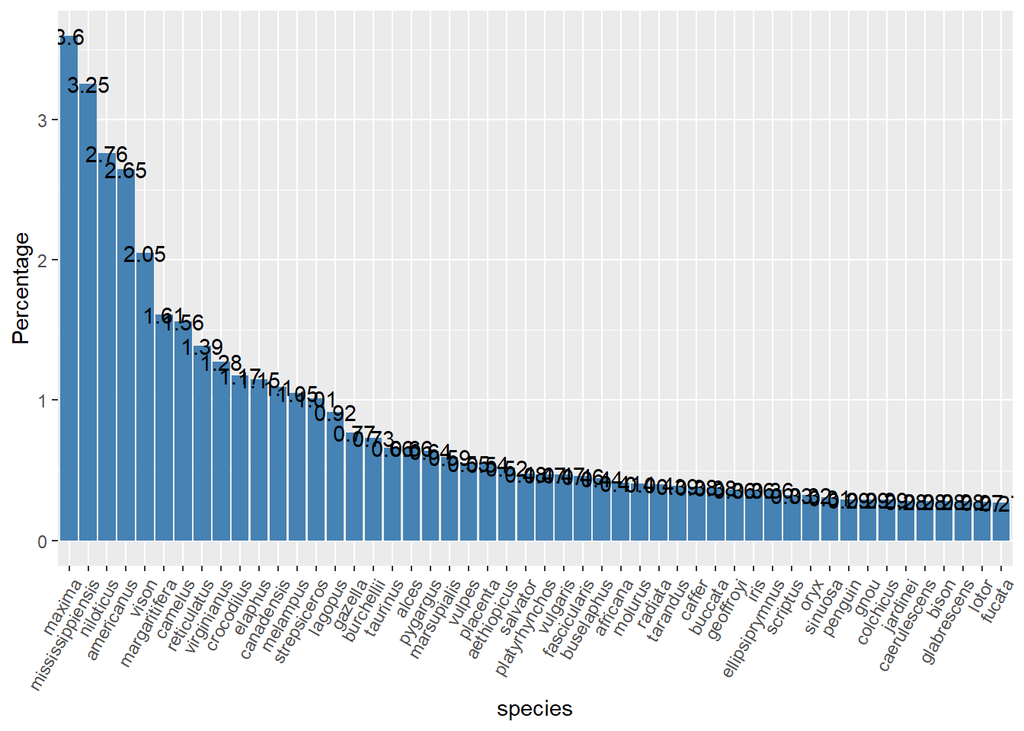

```r
species <-data_species %>% group_by(species) %>%
  summarise(total=n(), percentage= n()/nrow(data) *100) %>%
  drop_na(species) %>%
  arrange(desc(total)) %>% top_n(50, total)

ggplot(data=species, aes(x=reorder(species, -percentage), y=percentage)) +
  geom_bar(stat="identity",fill="steelblue") +
  geom_text(aes(label=round(percentage,2)))+
  theme(axis.text.x = element_text(hjust=1, angle=60)) +
  labs(y = "Percentage",  x="species")
```

```r
rm(data_species,species)
```

#### 3) Total value of the wildlife product(s) in US dollars, measured by disposition year

```r
value_wildlifeproduct_dispyear <-data %>%
  filter(!is.na(value))  %>%
  filter(!is.na(disposition_year))  %>%
  group_by(disposition_year) %>%
  summarise(value = sum(as.numeric(value)))

kable(value_wildlifeproduct_dispyear, format.args = list(big.mark = ",",
  scientific = FALSE))
```

| disposition_year | value |
| --- | --- |
| 1999 | 83,600 |
| 2000 | 1,155,450,447 |
| 2001 | 989,901,792 |
| 2002 | 1,019,935,228 |
| 2003 | 1,090,140,522 |
| 2004 | 1,375,461,986 |
| 2005 | 1,600,137,357 |
| 2006 | 1,690,832,159 |
| 2007 | 2,121,164,781 |
| 2008 | 13,871,305 |
| 2009 | 990,210 |
| 2010 | 981,469 |
| 2011 | 1,282,306,956 |
| 2012 | 2,774,318,151 |
| 2013 | 2,146,541,096 |
| 2014 | 2,974 |

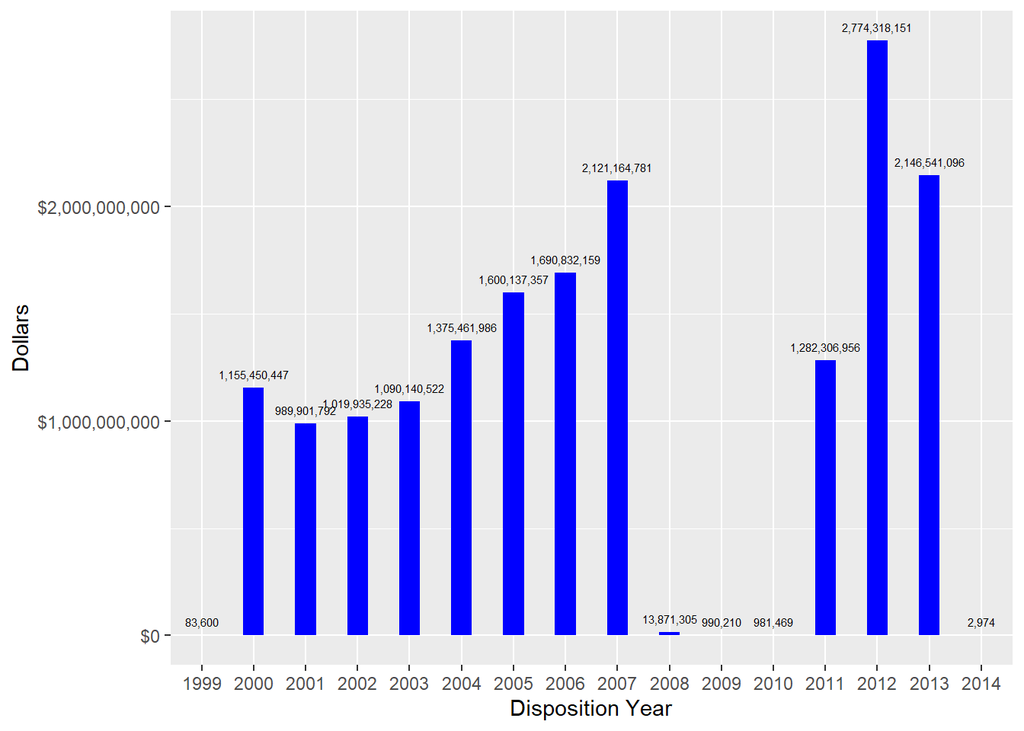

```r
ggplot(value_wildlifeproduct_dispyear, aes(x = disposition_year, y=value)) +
  geom_bar(stat = "identity", width=0.4, position = position_dodge(width=0.5),
           fill="blue") +
  geom_text(aes(label = scales::comma(value)), vjust=-1, size=2) +
  scale_y_continuous(labels = scales::dollar_format(prefix="$")) +
  labs(y = "Dollars",  x="Disposition Year")
```

#### 4) Total value of the wildlife product(s) in US dollars, measured by shipment year

```r
value_wildlifeproduct_shipyear <-data %>%
  filter(!is.na(value))  %>%
  filter(!is.na(shipment_year))  %>%
  group_by(shipment_year) %>%
  summarise(value = sum(as.numeric(value)))

kable(value_wildlifeproduct_shipyear, "markdown", format.args = list(big.mark = ",",
  scientific = FALSE), align = "r")
```

| shipment_year | value |
| --- | --- |
| 2000 | 1,169,449,246 |
| 2001 | 998,450,837 |
| 2002 | 1,013,252,694 |
| 2003 | 1,088,025,529 |
| 2004 | 1,384,529,129 |
| 2005 | 1,617,843,609 |
| 2006 | 1,692,721,975 |
| 2007 | 2,094,740,046 |
| 2011 | 1,294,868,593 |
| 2012 | 2,777,963,810 |
| 2013 | 2,130,336,518 |

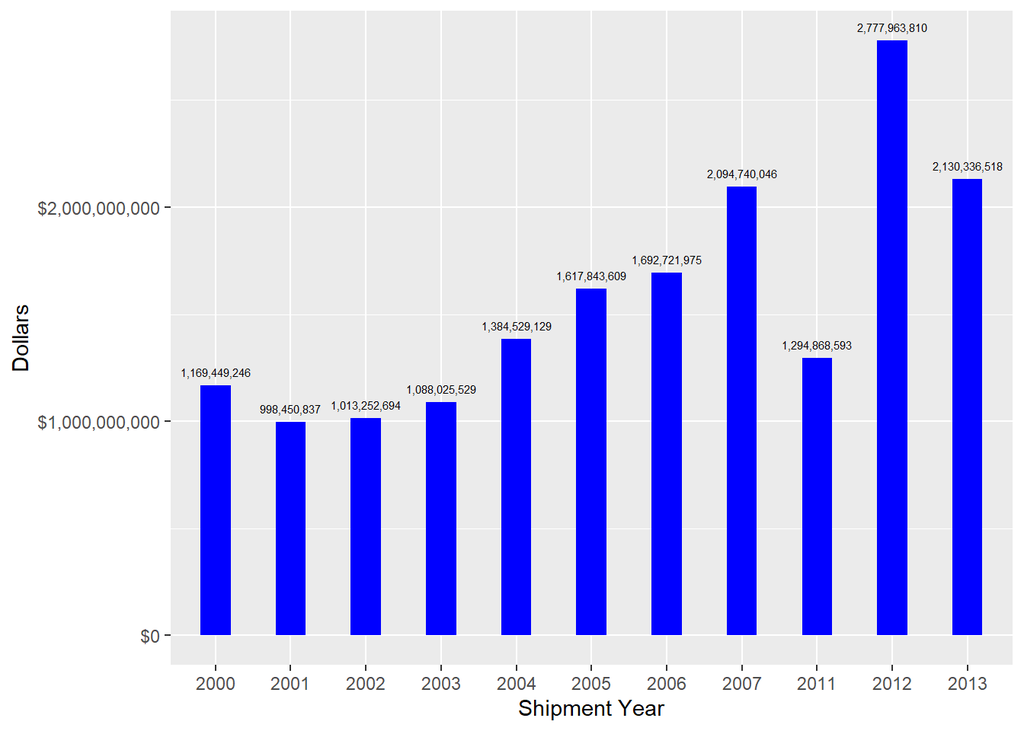

```r
ggplot(value_wildlifeproduct_shipyear, aes(x = shipment_year, y=value)) +
  geom_bar(stat = "identity", width=0.4, position = position_dodge(width=0.5),
           fill="blue") +
  geom_text(aes(label = scales::comma(value)), vjust=-1, size=2) +
  scale_y_continuous(labels = scales::dollar_format(prefix="$")) +
  labs(y = "Dollars",  x="Shipment Year")
```

#### 5) Quantity brought by year

```r
quantity_year<- data %>% filter(unit=="NO" | unit=="KG") # 5,107,119 -> 5,078,227
quantity_year_summary<- quantity_year %>% group_by(shipment_year, unit) %>%
  summarise(quantity = sum(quantity))

quantity_year_summary
```

```
## # A tibble: 30 x 3
## # Groups:   shipment_year [15]
##    shipment_year unit   quantity
##    <fct>         <fct>     <int>
##  1 2000          KG     29295638
##  2 2000          NO    660368186
##  3 2001          KG     30105748
##  4 2001          NO    833741141
##  5 2002          KG     35683521
##  6 2002          NO    806134730
##  7 2003          KG     30137632
##  8 2003          NO    769151810
##  9 2004          KG     32454703
## 10 2004          NO    784315580
## # ... with 20 more rows
```

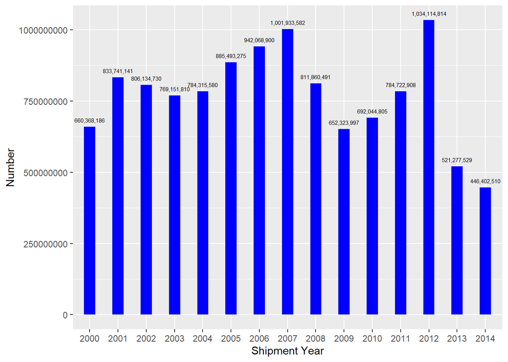

```r
# Number per year
ggplot(quantity_year_summary[quantity_year_summary$unit== "NO", ],
       aes(x = shipment_year, y=quantity)) +
       geom_bar(stat = "identity", width=0.4, position = position_dodge(width=0.5),
           fill="blue") +
       geom_text(aes(label = scales::comma(quantity)), vjust=-1, size=2) +
       labs(y = "Number",  x="Shipment Year")
```

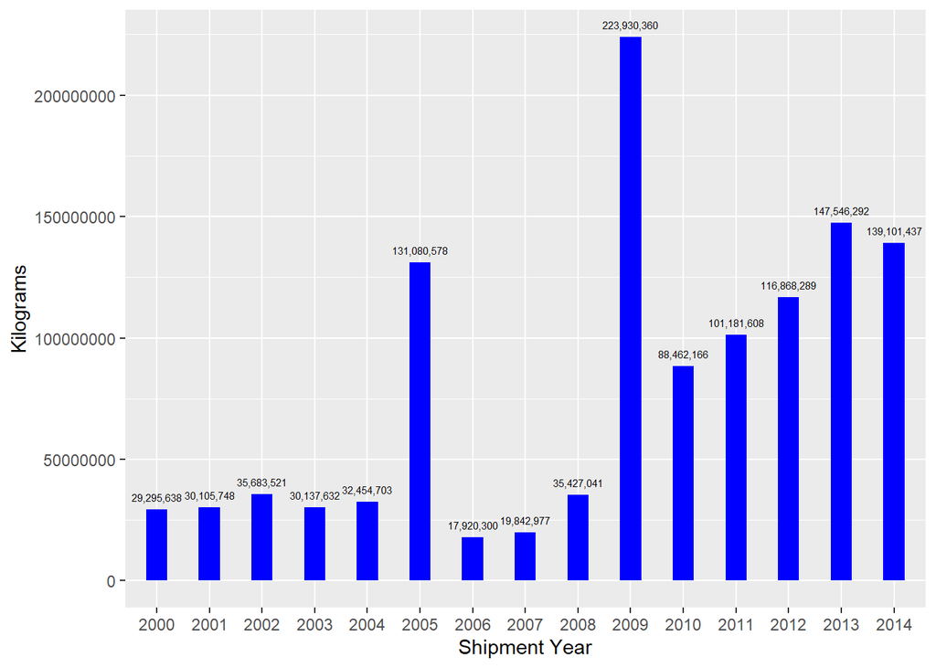

```r
# Kilograms per year
ggplot(quantity_year_summary[quantity_year_summary$unit== "KG", ],
       aes(x = shipment_year, y=quantity)) +
       geom_bar(stat = "identity", width=0.4, position = position_dodge(width=0.5),
           fill="blue") +
       geom_text(aes(label = scales::comma(quantity)), vjust=-1, size=2) +
       labs(y = "Kilograms",  x="Shipment Year")
```

Sources: https://www.iucnredlist.org/ , http://www.catalogueoflife.org/ , https://plants.usda.gov/classification.html